# Practical Machine Learning, Course Project

October 22, 2016

#### Setup

```r
knitr::opts_chunk$set(echo = TRUE)
library(caret)
library(randomForest)
library(gbm)
library(MASS)
library(ggplot2)
# set seed for reproducibility
set.seed(2016)
```

#### Load Data

```r
# data files must be in the working directory
pmltraining <- read.csv('pml-training.csv', na.strings = c("NA", "#DIV/0!", ""))
pmltesting <- read.csv('pml-testing.csv', na.strings = c("NA", "#DIV/0!", ""))
# after a quick review of these data files, there were numerous entries coded 'NA", or "#DIV/0', or just missing (''), thus the na.strings parameter was added to set all NA's to 'NA'.
```

### Introduction

This project evaluates data from accelerometers on the belt, forearm, arm, and dumbbell of 6 participants in a weight lifting exercise. They were asked to perform barbell lifts correctly and incorrectly in 5 different ways. More information is available from the website here: http://groupware.les.inf.puc-rio.br/har. The goal is to predict the manner in which they did the exercise. This is the `classe` variable in the training set `pmltraining`. The remaining variables in the data will be used to create a model to predict the activity. Finally, the prediction model will be used to predict 20 different test cases from the test data set `pmltesting`.

### Exploratory Data Analysis

The exploratory data analysis will start with a comparison of the users and the activity class with the dumbbell:

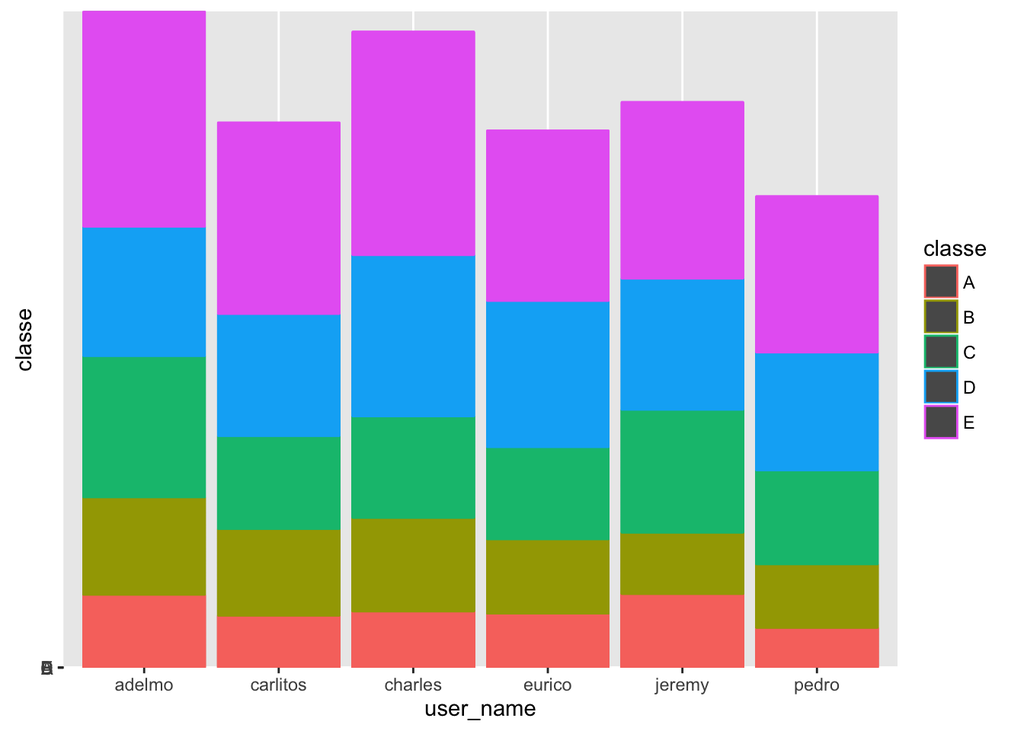

```r
ggplot(pmltraining, aes(x = user_name, y = classe, color = classe)) +
    geom_bar(stat='identity')
```

The two data sets have a large number of variables (160 columns):

```r
dim(pmltraining); dim(pmltesting)
```

```
## [1] 19622   160
```

```
## [1]  20 160
```

Before continuing, we need to deal with the large number of NA values in many of the data set columns. The following script will look at several of the 160 data columns, and then sum the number of ‘NA’ values in each column:

```r
str(pmltraining[1:15]); str(pmltraining[146:160])
```

```
## 'data.frame':    19622 obs. of  15 variables:
##  $ X                   : int  1 2 3 4 5 6 7 8 9 10 ...
##  $ user_name           : Factor w/ 6 levels "adelmo","carlitos",..: 2 2 2 2 2 2 2 2 2 2 ...
##  $ raw_timestamp_part_1: int  1323084231 1323084231 1323084231 1323084232 1323084232 1323084232 1323084232 1323084232 1323084232 1323084232 ...
##  $ raw_timestamp_part_2: int  788290 808298 820366 120339 196328 304277 368296 440390 484323 484434 ...
##  $ cvtd_timestamp      : Factor w/ 20 levels "02/12/2011 13:32",..: 9 9 9 9 9 9 9 9 9 9 ...
##  $ new_window          : Factor w/ 2 levels "no","yes": 1 1 1 1 1 1 1 1 1 1 ...
##  $ num_window          : int  11 11 11 12 12 12 12 12 12 12 ...
##  $ roll_belt           : num  1.41 1.41 1.42 1.48 1.48 1.45 1.42 1.42 1.43 1.45 ...
##  $ pitch_belt          : num  8.07 8.07 8.07 8.05 8.07 8.06 8.09 8.13 8.16 8.17 ...
##  $ yaw_belt            : num  -94.4 -94.4 -94.4 -94.4 -94.4 -94.4 -94.4 -94.4 -94.4 -94.4 ...
##  $ total_accel_belt    : int  3 3 3 3 3 3 3 3 3 3 ...
##  $ kurtosis_roll_belt  : num  NA NA NA NA NA NA NA NA NA NA ...
##  $ kurtosis_picth_belt : num  NA NA NA NA NA NA NA NA NA NA ...
##  $ kurtosis_yaw_belt   : logi  NA NA NA NA NA NA ...
##  $ skewness_roll_belt  : num  NA NA NA NA NA NA NA NA NA NA ...
```

```
## 'data.frame':    19622 obs. of  15 variables:
##  $ stddev_pitch_forearm: num  NA NA NA NA NA NA NA NA NA NA ...
##  $ var_pitch_forearm   : num  NA NA NA NA NA NA NA NA NA NA ...
##  $ avg_yaw_forearm     : num  NA NA NA NA NA NA NA NA NA NA ...
##  $ stddev_yaw_forearm  : num  NA NA NA NA NA NA NA NA NA NA ...
##  $ var_yaw_forearm     : num  NA NA NA NA NA NA NA NA NA NA ...
##  $ gyros_forearm_x     : num  0.03 0.02 0.03 0.02 0.02 0.02 0.02 0.02 0.03 0.02 ...
##  $ gyros_forearm_y     : num  0 0 -0.02 -0.02 0 -0.02 0 -0.02 0 0 ...
##  $ gyros_forearm_z     : num  -0.02 -0.02 0 0 -0.02 -0.03 -0.02 0 -0.02 -0.02 ...
##  $ accel_forearm_x     : int  192 192 196 189 189 193 195 193 193 190 ...
##  $ accel_forearm_y     : int  203 203 204 206 206 203 205 205 204 205 ...
##  $ accel_forearm_z     : int  -215 -216 -213 -214 -214 -215 -215 -213 -214 -215 ...
##  $ magnet_forearm_x    : int  -17 -18 -18 -16 -17 -9 -18 -9 -16 -22 ...
##  $ magnet_forearm_y    : num  654 661 658 658 655 660 659 660 653 656 ...
##  $ magnet_forearm_z    : num  476 473 469 469 473 478 470 474 476 473 ...
##  $ classe              : Factor w/ 5 levels "A","B","C","D",..: 1 1 1 1 1 1 1 1 1 1 ...
```

```r
# figure out which columns have NA's and count them
na1 <- apply(pmltraining, 2, function(x) sum(is.na(x)))
na2 <- apply(pmltesting, 2, function(x) sum(is.na(x)))
table(na1); table(na2)
```

```
## na1
##     0 19216 19217 19218 19220 19221 19225 19226 19227 19248 19293 19294
##    60    67     1     1     1     4     1     4     2     2     1     1
## 19296 19299 19300 19301 19622
##     2     1     4     2     6
```

```
## na2
##   0  20
##  60 100
```

```r
pmlNoNA <- pmltraining[, na1==0]
pmlNoNA <- pmlNoNA[, 7:60]
dim(pmlNoNA)
```

```
## [1] 19622    54
```

```r
# perform same cleaning of the pmltesting data set to match pm1NoNA
pmltestNoNA <- pmltesting[, na1==0]
pmltestNoNA <- pmltestNoNA[, 7:60]
dim(pmltestNoNA)
```

```
## [1] 20 54
```

There are still quite a few prediction variables, 53, so we should determine if any have low variability that will not be good predictors. The `nearZeroVar` function from the `caret` package will help identify any such variables as candidates for removal.

```r
nearZeroVar(pmlNoNA, saveMetrics = TRUE)
```

```
##                      freqRatio percentUnique zeroVar   nzv
## num_window            1.000000     4.3726430   FALSE FALSE
## roll_belt             1.101904     6.7781062   FALSE FALSE
## pitch_belt            1.036082     9.3772296   FALSE FALSE
## yaw_belt              1.058480     9.9734991   FALSE FALSE
## total_accel_belt      1.063160     0.1477933   FALSE FALSE
## gyros_belt_x          1.058651     0.7134849   FALSE FALSE
## gyros_belt_y          1.144000     0.3516461   FALSE FALSE
## gyros_belt_z          1.066214     0.8612782   FALSE FALSE
## accel_belt_x          1.055412     0.8357966   FALSE FALSE
## accel_belt_y          1.113725     0.7287738   FALSE FALSE
## accel_belt_z          1.078767     1.5237998   FALSE FALSE
## magnet_belt_x         1.090141     1.6664968   FALSE FALSE
## magnet_belt_y         1.099688     1.5187035   FALSE FALSE
## magnet_belt_z         1.006369     2.3290184   FALSE FALSE
## roll_arm             52.338462    13.5256345   FALSE FALSE
## pitch_arm            87.256410    15.7323412   FALSE FALSE
## yaw_arm              33.029126    14.6570176   FALSE FALSE
## total_accel_arm       1.024526     0.3363572   FALSE FALSE
## gyros_arm_x           1.015504     3.2769341   FALSE FALSE
## gyros_arm_y           1.454369     1.9162165   FALSE FALSE
## gyros_arm_z           1.110687     1.2638875   FALSE FALSE
## accel_arm_x           1.017341     3.9598410   FALSE FALSE
## accel_arm_y           1.140187     2.7367241   FALSE FALSE
## accel_arm_z           1.128000     4.0362858   FALSE FALSE
## magnet_arm_x          1.000000     6.8239731   FALSE FALSE
## magnet_arm_y          1.056818     4.4439914   FALSE FALSE
## magnet_arm_z          1.036364     6.4468454   FALSE FALSE
## roll_dumbbell         1.022388    84.2065029   FALSE FALSE
## pitch_dumbbell        2.277372    81.7449801   FALSE FALSE
## yaw_dumbbell          1.132231    83.4828254   FALSE FALSE
## total_accel_dumbbell  1.072634     0.2191418   FALSE FALSE
## gyros_dumbbell_x      1.003268     1.2282132   FALSE FALSE
## gyros_dumbbell_y      1.264957     1.4167771   FALSE FALSE
## gyros_dumbbell_z      1.060100     1.0498420   FALSE FALSE
## accel_dumbbell_x      1.018018     2.1659362   FALSE FALSE
## accel_dumbbell_y      1.053061     2.3748853   FALSE FALSE
## accel_dumbbell_z      1.133333     2.0894914   FALSE FALSE
## magnet_dumbbell_x     1.098266     5.7486495   FALSE FALSE
## magnet_dumbbell_y     1.197740     4.3012945   FALSE FALSE
## magnet_dumbbell_z     1.020833     3.4451126   FALSE FALSE
## roll_forearm         11.589286    11.0895933   FALSE FALSE
## pitch_forearm        65.983051    14.8557741   FALSE FALSE
## yaw_forearm          15.322835    10.1467740   FALSE FALSE
## total_accel_forearm   1.128928     0.3567424   FALSE FALSE
## gyros_forearm_x       1.059273     1.5187035   FALSE FALSE
## gyros_forearm_y       1.036554     3.7763735   FALSE FALSE
## gyros_forearm_z       1.122917     1.5645704   FALSE FALSE
## accel_forearm_x       1.126437     4.0464784   FALSE FALSE
## accel_forearm_y       1.059406     5.1116094   FALSE FALSE
## accel_forearm_z       1.006250     2.9558659   FALSE FALSE
## magnet_forearm_x      1.012346     7.7667924   FALSE FALSE
## magnet_forearm_y      1.246914     9.5403119   FALSE FALSE
## magnet_forearm_z      1.000000     8.5771073   FALSE FALSE
## classe                1.469581     0.0254816   FALSE FALSE
```

In this case, no variables were found to have low variability, so no further reduction of variables will be performed.

The data set is now reduced to a ‘clean’ data set with no ‘NA’ values, with 19622 observations of 53 explanatory variables and the response variable `classe` in the 54th column. The `plmtesting` data set is also reduced to just the 20 ‘test’ observations of 53 explanatory variables for later use, plus the 54th column containing the test id. The ‘clean’ data set will be further divided into training and testing data sets for use in building the model:

```r
# split the 'pmlNoNA' data set so that we have a 'training' and 'testing' data set use prior to the final validation using 'pmltestNoNA'
inTrain <- createDataPartition(y=pmlNoNA$classe, p=0.75, list=FALSE)
training <- pmlNoNA[inTrain,]
testing <- pmlNoNA[-inTrain,]
dim(training);dim(testing)
```

```
## [1] 14718    54
```

```
## [1] 4904   54
```

### Build a Model for Prediction

Now that the `training` and `testing` data sets are finalized with 53 explanatory variables, several models will be tested for accuracy. Cross validation will be accomplished by using the `trainControl` setting `method = 'cv'`, with the default of 10 k-folds. The first model will try predicting with trees using the `rpart` option:

```r
# set trainControl to use cross-validation in all models
tc <- trainControl(method = 'cv')
# build a model and predict, using method = 'rpart'
modelrpart <- train(classe ~ ., method = 'rpart', trControl = tc, data = training)
predrpart <- predict(modelrpart, newdata = testing)
confusionMatrix(predrpart, testing$classe)$overall[1]
```

```
##  Accuracy
## 0.5252855
```

This model resulted in very poor accuracy of 0.525, which is not that much better than random chance. The next model will try linear discriminant analysis with `lda`:

```r
# build a model and predict with method = 'lda'
modellda <- train(classe ~ ., method = 'lda', trControl = tc, data = training)
predlda <- predict(modellda, newdata = testing)
confusionMatrix(predlda, testing$classe)$overall[1]
```

```
##  Accuracy
## 0.7175775
```

The accuracy of this model is better at 0.718. One more model will be fitted, this time using a random forest method:

```r
# note: using train() and method = 'rf' resulted in a very long run time, so the randomForest package is used instead
modelrf <- randomForest(classe ~ ., data = training, trControl = tc, ntree=200)
predrf <- predict(modelrf, newdata = testing)
confusionMatrix(predrf, testing$classe)$overall[1]
```

```
##  Accuracy
## 0.9987765
```

The resulting accuracy is very good at 0.999. This model will be used for further prediction.

### Expected out of sample error

The out of sample error is shown by the follow table generated from the `confusionMatrix` command. The table shows the reference cases from the `classe` variable in the `testing` data set, against the predicted values using the `modelrf` model on the explanatory variables in `testing`:

```r
oosError <- confusionMatrix(predrf, testing$classe)
oosError$overall[1]
```

```
##  Accuracy
## 0.9987765
```

```r
oosError$table
```

```
##           Reference
## Prediction    A    B    C    D    E
##          A 1395    1    0    0    0
##          B    0  946    1    0    0
##          C    0    2  854    2    0
##          D    0    0    0  802    0
##          E    0    0    0    0  901
```

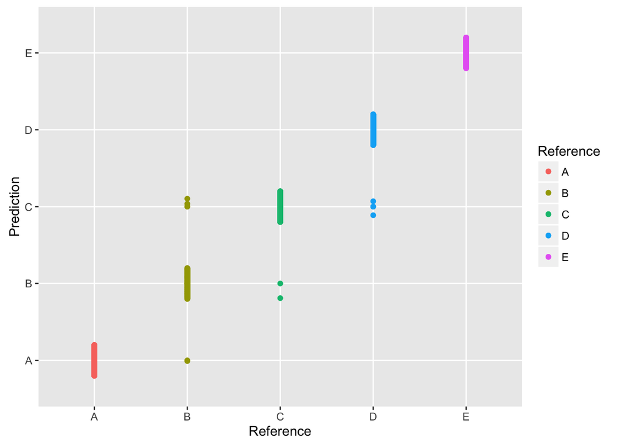

```r
Reference <- (testing$classe)
Prediction <- (predrf)
xy <- data.frame(Reference, Prediction)
ggplot(xy, aes(x = Reference, y = Prediction, color = Reference)) + geom_point() + geom_jitter(width = 0, height = 0.5)
```

### Prediction

Finally, the last step is to use the chosen model, `modelrf`, to predict the `classe` values of the 20 test cases given in the `pmltesting` data set:

```r
quizPred <-  predict(modelrf, newdata = pmltestNoNA)
quizPred
```

```
##  1  2  3  4  5  6  7  8  9 10 11 12 13 14 15 16 17 18 19 20
##  B  A  B  A  A  E  D  B  A  A  B  C  B  A  E  E  A  B  B  B
## Levels: A B C D E
```